# DS421 semester 2 final project

@xrwang

5/3/2018

#Contents

This is a final project PDF document for DS421 stitched together from other experiments in this rpo.

Some major goals were: - Get satellite data/imagery for village and county names. - Poke around household income data - Poke around land use change for a few Taobao villages.

## Section A

We’ll also poke at the data a bit, looking at changes over time.

## Section B

##CHIP

CHIP (China Household Income Project) is put out by the CIID Beijing as a longitudinal survey. It’s been happening since 1988 and includes all kinds of juicy stuff including land use.

Load up necessary libraries. Some data is in `.dta` which is Stata file.

```r
library(tidyr)
library(tidyverse)
library(dplyr)
library(foreign)
library(reticulate)
library(haven)
library(ggmap)
library(sf)
```

```r
library(raster)
library(spData)        # load geographic data
library(httr)
library(jsonlite)
library(mapview)
library(leaflet)
```

```r
chips_rur_1988 <- read_dta('data/1988/09836-0002-Data.dta')
chips_rur_1995 <- read_tsv('data/1995/DS0002/03012-0002-Data.tsv')
chips_rur_2002<- read_tsv('data/2002/DS0006/21741-0006-Data.tsv')
chips_rur_2007abc <- read_dta('data/2007 (2008)/RHS_w1_abc.dta')
chips_rur_2007d <- read_dta('data/2007 (2008)/RHS_w1_d.dta')
chips_rur_2007e1 <- read_dta('data/2007 (2008)/RHS_w1_e1.dta')
chips_rur_2007e2 <- read_dta('data/2007 (2008)/RHS_w1_e2.dta')
chips_rur_2007e3 <- read_dta('data/2007 (2008)/RHS_w1_e3.dta')
chips_rur_2007e4 <- read_dta('data/2007 (2008)/RHS_w1_e4.dta')
chips_rur_2007hhiexp <- read_dta('data/2007 (2008)/CHIP2007_income_and_expenditure_20150408.dta')
chips_rur_2008abc <- read_dta('data/2008 (2009)/RHS_w2_abc.dta')
chips_rur_2008d <- read_dta('data/2008 (2009)/RHS_w2_d.dta')
chips_rur_2008e <- read_dta('data/2008 (2009)/RHS_w2_e.dta')
chips_rur_2008f <- read_dta('data/2008 (2009)/RHS_w2_f.dta')
chips_rur_2008hgsg <- read_dta('data/2008 (2009)/RHS_w2_hgsg.dta')
chips_rur_2008hijk <- read_dta('data/2008 (2009)/RHS_w2_hijk.dta')
chips_rur_2008vill <- read_dta('data/2008 (2009)/RHS_w2_vill.dta')
chips_rur_2013 <- read_dta('data/2013/CHIP2013_rural_household_f_income_asset.dta')


name_vill_id_2007 <- read_dta('data/2007 (2008)/name_id_and_village_id_20151010.dta')
```

### Table of columns used:

| Year | Net household income | Land cultivated | Number of rooms in House | Fixed production assets | Total household exp on production |
| --- | --- | --- | --- | --- | --- |
| 1988 | HNET88 | LAT | HHO | VHPFP | EFP88 |
| 1995 | B602 | B801 | B1001 | B804_1 | B7130 |
| 2002 | na | na | na | na | na |
| 2007 | income_net | na | na | na | na |
| 2009 | na | H01 | na | K01 | na |
| 2013 | F01_1 | L01_1 | na | F07_1 + F07_2 | F02_1 |

```r
# Filter out some data from 1988 because there's missing values. They got rid of missing values in later datasets.

chips_rur_1988_filt <- chips_rur_1988 %>% filter(HNET88 != 99999999, LAT != 999.9, HHO != 99, VHPFP != 99999, EFP88 != 99999999 )

base::mean(chips_rur_1988_filt$HNET88)
```

```
## [1] 2739.51
```

```r
base::mean(chips_rur_1995$B602)
```

```
## [1] 6812.06
```

```r
base::mean(chips_rur_2007hhiexp$income_net)
```

```
## [1] 19451.19
```

```r
base::mean(chips_rur_2013$f01_1, na.rm=TRUE)
```

```
## [1] 45654.01
```

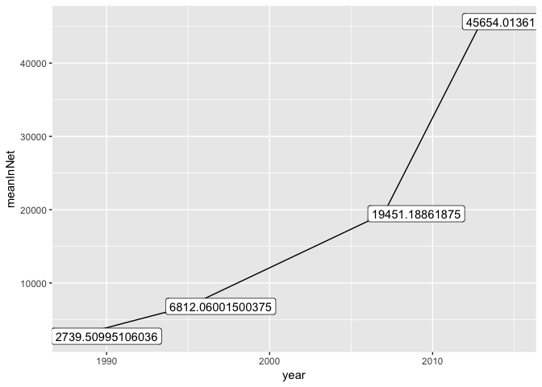

```r
meanNetIncome <- new_tibble(list(year = c(1988,1995,2007,2013),
                     meanInNet = c(base::mean(chips_rur_1988_filt$HNET88), base::mean(chips_rur_1995$B602), base::mean(chips_rur_2007hhiexp$income_net), base::mean(chips_rur_2013$f01_1, na.rm=TRUE))))

ggplot(meanNetIncome, aes(year, meanInNet)) +
  geom_line() +
  geom_point() +
  geom_label(label=meanNetIncome$meanInNet, nudge_x = 2, nudge_y = 1)
```

```r
chips_rur_1988_filt <- chips_rur_1988_filt %>%
  mutate(., PROVCOUNTY = paste0(PROVINCE, COUNTY))

chips_rur_1988_filt$UCODE <- substr(chips_rur_1988_filt$UCODE, 1,6)


#A1 is county and city code
chips_rur_1995 %>%
  mutate(., PROVCOUNTY = paste0(PROVINCE, COUNTY))
```

```
## # A tibble: 7,998 x 262
##        A1  B101  B401  B402  B403  B404  B405  B406  B407 B407A  B408
##     <int> <int> <int> <int> <int> <int> <int> <int> <int> <int> <int>
##  1 110221   101     1     1     2     2     2     2     2     0     1
##  2 110221   102     1     1     2     2     2     2     2     0     1
##  3 110221   103     1     1     2     2     2     2     2     0     1
##  4 110221   104     1     1     2     2     2     2     2     0     1
##  5 110221   105     1     1     2     2     2     2     2     0     1
##  6 110221   106     1     1     2     2     2     2     2     0     1
##  7 110221   107     1     1     2     2     2     2     2     0     1
##  8 110221   108     1     1     2     2     2     2     2     0     1
##  9 110221   109     1     1     2     2     2     2     2     0     1
## 10 110221   110     1     1     2     2     2     2     2     0     1
## # ... with 7,988 more rows, and 251 more variables: B409 <int>,
## #   B410 <int>, B411 <int>, B412 <int>, B412A <int>, B412B <int>,
## #   B412C <int>, B412D <int>, B413 <int>, B414 <int>, B501_1 <int>,
## #   B501_2 <int>, B501_3 <int>, B501A_1 <int>, B501A_2 <int>,
## #   B501A_3 <int>, B501B_1 <int>, B501B_2 <int>, B501B_3 <int>,
## #   B501C_1 <int>, B501C_2 <int>, B501C_3 <int>, B501D_1 <int>,
## #   B501D_2 <int>, B501D_3 <int>, B501E_1 <int>, B501E_2 <int>,
## #   B501E_3 <int>, B501F_1 <int>, B501F_2 <int>, B501F_3 <int>,
## #   B502_1 <int>, B502_2 <int>, B502_3 <int>, B502A_1 <int>,
## #   B502A_2 <int>, B502A_3 <int>, B502B_1 <int>, B502B_2 <int>,
## #   B502B_3 <int>, B502C_1 <int>, B502C_2 <int>, B502C_3 <int>,
## #   B502D_1 <int>, B502D_2 <int>, B502D_3 <int>, B502E_1 <int>,
## #   B502E_2 <int>, B502E_3 <int>, B502F_1 <int>, B502F_2 <int>,
## #   B502F_3 <int>, B502G_1 <int>, B502G_2 <int>, B502G_3 <int>,
## #   B502H_1 <int>, B502H_2 <int>, B502H_3 <int>, B503 <int>, B504 <int>,
## #   B504A <int>, B504B <int>, B504C <int>, B505 <int>, B506 <int>,
## #   B506A <int>, B506B <int>, B507 <int>, B508 <int>, B509 <int>,
## #   B510 <int>, B511_1 <int>, B511_2 <int>, B511A_1 <int>, B511A_2 <int>,
## #   B511B_1 <int>, B511B_2 <int>, B511C_1 <int>, B511C_2 <int>,
## #   B511D_1 <int>, B511D_2 <int>, B600 <int>, B601 <int>, B602 <int>,
## #   B700 <int>, B700A <int>, B701 <int>, B702 <int>, B703 <int>,
## #   B703A <int>, B703B <int>, B704 <int>, B705 <int>, B706 <int>,
## #   B707 <int>, B708 <int>, B708A <int>, B708B <int>, B708C <int>,
## #   B709 <int>, …
```

```r
chips_rur_2007hhiexp$name_id <- substr(chips_rur_2007hhiexp$name_id, 1, 6)
```

##County level variations in income

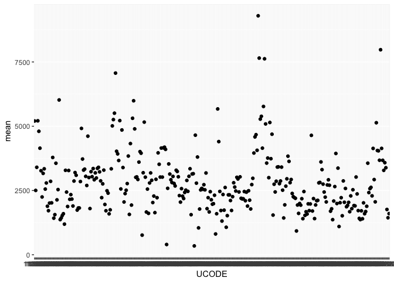

```r
chips_rur_1988_filt %>%
  group_by(UCODE) %>%
  summarise(mean = base::mean(HNET88)) %>%
  mutate(., diff_from_country_mean = mean-base::mean(chips_rur_1988_filt$HNET88)) %>%
  ggplot(aes(UCODE,mean)) +
           geom_point()
```

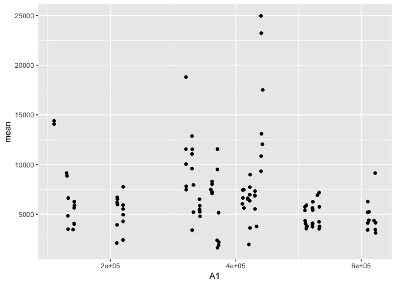

```r
chips_rur_1995 %>%
  group_by(A1) %>%
  summarise(mean=base::mean(B602)) %>%
  mutate(., diff_from_country_mean = mean-base::mean(chips_rur_1995$B602))  %>%
  ggplot(aes(A1,mean)) +
           geom_point()
```

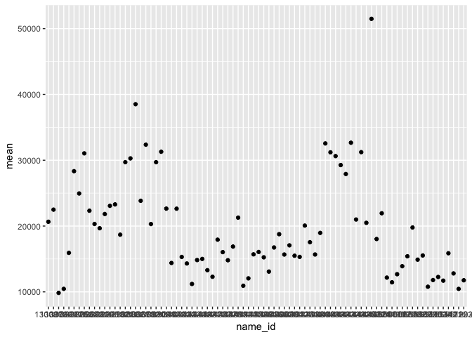

```r
chips_rur_2007hhiexp %>%
  group_by(name_id) %>%
  summarise(mean=base::mean(income_net)) %>%
  mutate(., diff_from_country_mean = mean-base::mean(chips_rur_2007hhiexp$income_net)) %>%
  ggplot(aes(name_id,mean)) +
           geom_point()
```

```r
chips_rur_2007hhiexp %>%
  group_by(name_id)
```

```
## # A tibble: 8,000 x 14
## # Groups:   name_id [82]
##    name_id  exp1   exp2   exp3   exp4  exp5   exp6   exp7    exp8
##    <chr>   <dbl>  <dbl>  <dbl>  <dbl> <dbl>  <dbl>  <dbl>   <dbl>
##  1 130181  2670.    0.   2239. 1778.   971.  520.   386.    12.0
##  2 130181  9633. 5364.   8978. 6396.   786. 1935.  1687.  1946.
##  3 130181  4012.  442.   1941.  180.   120.  134.    13.0    3.00
##  4 130181  9487. 1986.   5853. 1020.   884. 4192.   386.   357.
##  5 130181  3371. 1174.   2750.  712.   290.  270.    44.7   34.3
##  6 130181  6559.   47.0 20386.  147.   432.  120.   102.    14.0
##  7 130181  4449.  293.   1748.  201.  1254.  374.   118.    47.3
##  8 130181  6968.  808.   1072.  147.   300.   69.2   72.0   65.4
##  9 130181  3518.  742.   1344.  246.   567. 1162.   564.   137.
## 10 130181  3805.  414.   9059.   48.0  959.  400.   473.   114.
## # ... with 7,990 more rows, and 5 more variables: income_net <dbl>,
## #   income_net_1 <dbl>, income_net_2 <dbl>, income_net_3 <dbl>,
## #   income_net_4 <dbl>
```

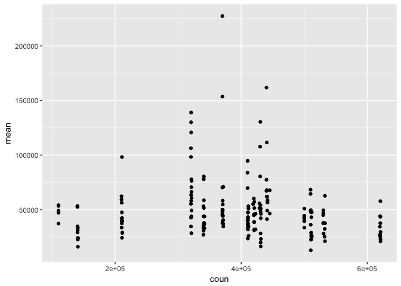

```r
chips_rur_2013 %>%
  group_by(coun) %>%
  summarise(mean=base::mean(f01_1)) %>%
  mutate(., diff_from_country_mean = mean-base::mean(chips_rur_2013$f01_1, na.rm=TRUE)) %>%
  ggplot(aes(coun,mean)) +
           geom_point()
```

##dice off last 3 digits from `name id` of chips_rur_2007hhiexp

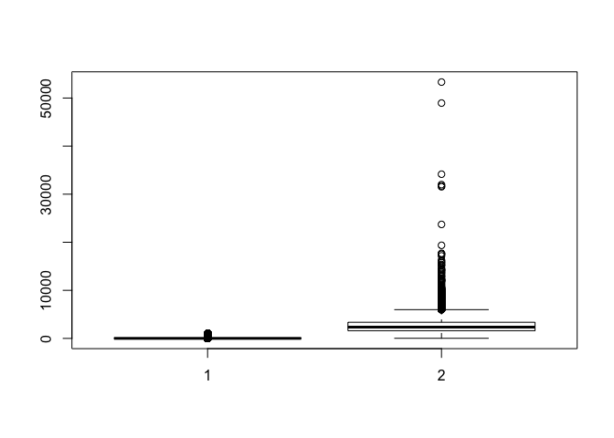

```r
outlier_values_1988 <- boxplot.stats(chips_rur_1988_filt$HNET88)$out  # outlier values.
outlier_values_1995 <- boxplot.stats(chips_rur_1995$B602)$out  # outlier values.
outlier_values_2007 <- boxplot.stats(chips_rur_2007hhiexp$income_net)$out  # outlier values.
outlier_values_2013 <- boxplot.stats(chips_rur_2013$f01_1)$out  # outlier values.
boxplot(chips_rur_1988_filt$LAT, chips_rur_1988_filt$HNET88)
```

## Geocode county addresses based off the county codes

Data from https://raw.githubusercontent.com/modood/Administrative-divisions-of-China/, basically there’s a county code and name for each county. They are not geocoded however (by geocoded I mean “center” of county).

#Add long lat columns to the county code table

```r
counties_main <- read_csv('https://raw.githubusercontent.com/modood/Administrative-divisions-of-China/master/dist/areas.csv')

counties_main
```

```
## # A tibble: 2,856 x 4
##      code name     cityCode provinceCode
##     <int> <chr>       <int>        <int>
##  1 110101 东城区       1101           11
##  2 110102 西城区       1101           11
##  3 110105 朝阳区       1101           11
##  4 110106 丰台区       1101           11
##  5 110107 石景山区     1101           11
##  6 110108 海淀区       1101           11
##  7 110109 门头沟区     1101           11
##  8 110111 房山区       1101           11
##  9 110112 通州区       1101           11
## 10 110113 顺义区       1101           11
## # ... with 2,846 more rows
```

```r
counties_main$lat <- 'NA'
counties_main$long <- 'NA'

city_main <- read_csv('https://raw.githubusercontent.com/modood/Administrative-divisions-of-China/master/dist/cities.csv')
province_main <- read_csv('https://raw.githubusercontent.com/modood/Administrative-divisions-of-China/master/dist/provinces.csv')

prov_county_main <- left_join(counties_main, province_main,
                              by=c('provinceCode'='code'))

prov_county_main <- prov_county_main %>%
    rename('cityName' = name.y,
           'countyName' = name.x) %>%
    mutate(., geocodeAdd = paste0(cityName,countyName))


prov_county_main
```

```
## # A tibble: 2,856 x 8
##      code countyName cityCode provinceCode lat   long  cityName geocodeAdd
##     <int> <chr>         <int>        <int> <chr> <chr> <chr>    <chr>
##  1 110101 东城区         1101           11 NA    NA    北京市   北京市东城区…
##  2 110102 西城区         1101           11 NA    NA    北京市   北京市西城区…
##  3 110105 朝阳区         1101           11 NA    NA    北京市   北京市朝阳区…
##  4 110106 丰台区         1101           11 NA    NA    北京市   北京市丰台区…
##  5 110107 石景山区       1101           11 NA    NA    北京市   北京市石景山区…
##  6 110108 海淀区         1101           11 NA    NA    北京市   北京市海淀区…
##  7 110109 门头沟区       1101           11 NA    NA    北京市   北京市门头沟区…
##  8 110111 房山区         1101           11 NA    NA    北京市   北京市房山区…
##  9 110112 通州区         1101           11 NA    NA    北京市   北京市通州区…
## 10 110113 顺义区         1101           11 NA    NA    北京市   北京市顺义区…
## # ... with 2,846 more rows
```

## Batch geocode using ggmap, h/t shayne lynn

# Set an API key for ggmap so we don’t go over the limit

```r
ggmap_credentials()
register_google(key='insertyourkeyhere')
library(ggmap)
ggmap_credentials()
```

## Divide the table into two so as to preempt going over the free geocoding limit

```r
# pcoun_codes_1 <- filter(prov_county_main, code < 400000)
# pcoun_codes_2 <- filter(prov_county_main, code >= 400000)
```

This section is commented out to prevent geocoding thousands of rows everytime we knit….

```r
# infile <- 'pcoun_2'
# data <-pcoun_codes_2
#
# addresses = data$geocodeAdd
#
# #define a function that will process googles server responses for us.
# getGeoDetails <- function(address){
#    #use the gecode function to query google servers
#    geo_reply = geocode(address, output='all', messaging=TRUE, override_limit=TRUE)
#    #now extract the bits that we need from the returned list
#
#    answer <- data.frame(lat=NA, long=NA, accuracy=NA, formatted_address=NA, address_type=NA, status=NA)
#    answer$status <- geo_reply$status
#
#    #if we are over the query limit - want to pause for an hour
#    while(geo_reply$status == "OVER_QUERY_LIMIT"){
#        print("OVER QUERY LIMIT - Pausing for 1 hour at:")
#        time <- Sys.time()
#        print(as.character(time))
#        Sys.sleep(60*60)
#        geo_reply = geocode(address, output='all', messaging=TRUE, override_limit=TRUE)
#        answer$status <- geo_reply$status
#    }
#
#    #return Na's if we didn't get a match:
#    if (geo_reply$status != "OK"){
#        return(answer)
#    }
#    #else, extract what we need from the Google server reply into a dataframe:
#    answer$lat <- geo_reply$results[[1]]$geometry$location$lat
#    answer$long <- geo_reply$results[[1]]$geometry$location$lng
#    if (length(geo_reply$results[[1]]$types) > 0){
#        answer$accuracy <- geo_reply$results[[1]]$types[[1]]
#    }
#    answer$address_type <- paste(geo_reply$results[[1]]$types, collapse=',')
#    answer$formatted_address <- geo_reply$results[[1]]$formatted_address
#
#    return(answer)
# }
#
# #initialise a dataframe to hold the results
# geocoded <- data.frame()
# # find out where to start in the address list (if the script was interrupted before):
# startindex <- 1
# #if a temp file exists - load it up and count the rows!
# tempfilename <- paste0(infile, '_temp_geocoded.rds')
# if (file.exists(tempfilename)){
#        print("Found temp file - resuming from index:")
#        geocoded <- readRDS(tempfilename)
#        startindex <- nrow(geocoded)+1
#        print(startindex)
# }
#
# # Start the geocoding process - address by address. geocode() function takes care of query speed limit.
# for (ii in seq(startindex, length(addresses))) {
#    print(paste("Working on index", ii, "of", length(addresses)))
#    #query the google geocoder - this will pause here if we are over the limit.
#
#    result = getGeoDetails(addresses[ii])
#    print(result$status)
#    result$index <- ii
#    #append the answer to the results file.
#    geocoded <- rbind(geocoded, result)
#    #save temporary results as we are going along
#    saveRDS(geocoded, tempfilename)
# }

# geocodedTable <- data.frame(matrix(ncol = 3, nrow = 1516))
# #now we add the latitude and longitude to the main data
#
# geocodedTable$status <- geocoded$status
# geocodedTable$formatted_address <- geocoded$formatted_address
# geocodedTable$index <- geocoded$index
# geocodedTable$lat <- geocoded$lat
# geocodedTable$long <- geocoded$long
# geocodedTable$accuracy <- geocoded$accuracy
#
#
#
# #finally write it all to the output files
# saveRDS(data, paste0("../data/", infile ,"_geocoded.rds"))
# write.table(geocodedTable, file=paste0("", infile ,"_geocoded.csv"), sep=",", row.names=FALSE)
```

# Now there’s two tables because we split the county list, put together vertically

```r
a <- read_csv('data/pcoun_1_geocoded.csv')
b <- read_csv('data/pcoun_2_geocoded.csv')
geocoded_areas <- bind_rows(a,b)

prov_county_main$lat <- geocoded_areas$lat
prov_county_main$long <- geocoded_areas$long

prov_county_main$engAdd <- geocoded_areas$formatted_address
```

## Join prov_county_main to the tables

```r
chips_rur_1988_filt$UCODE <- strtoi(chips_rur_1988_filt$UCODE)
prov_county_main
```

```
## # A tibble: 2,856 x 9
##      code countyName cityCode provinceCode   lat  long cityName geocodeAdd
##     <int> <chr>         <int>        <int> <dbl> <dbl> <chr>    <chr>
##  1 110101 东城区         1101           11  39.9  116. 北京市   北京市东城区…
##  2 110102 西城区         1101           11  39.9  116. 北京市   北京市西城区…
##  3 110105 朝阳区         1101           11  39.9  116. 北京市   北京市朝阳区…
##  4 110106 丰台区         1101           11  39.9  116. 北京市   北京市丰台区…
##  5 110107 石景山区       1101           11  39.9  116. 北京市   北京市石景山区…
##  6 110108 海淀区         1101           11  40.0  116. 北京市   北京市海淀区…
##  7 110109 门头沟区       1101           11  39.9  116. 北京市   北京市门头沟区…
##  8 110111 房山区         1101           11  39.7  116. 北京市   北京市房山区…
##  9 110112 通州区         1101           11  39.9  117. 北京市   北京市通州区…
## 10 110113 顺义区         1101           11  40.1  117. 北京市   北京市顺义区…
## # ... with 2,846 more rows, and 1 more variable: engAdd <chr>
```

```r
chips_rur_1988_geocoded <- chips_rur_1988_filt %>%
  inner_join(prov_county_main, by=c('UCODE'='code')) %>%
  na.omit()
```

## Maps of survey locations

```r
leaflet(data = chips_rur_1988_geocoded) %>%
  addTiles() %>%
  addMarkers(~long, ~lat, popup = ~as.character(HNET88), label = ~as.character(HNET88))
```

[interactive chart not shown]

# Taobao villages

## Geocoding taobao villages

There are 1312 taobao villages as of 2017.

I have data for Taobao villages from 2014-2016

Testing out the geocoding response, put the province and village together (省 column + 村 column, separate by comma )

```r
taobao_villages_2016 <- read_csv('data/taobao-village-list/taobao_village_list_2016.csv',
                            col_names = c(
                              'sheng',
                              'shi',
                              'xian',
                              'xiangzhen',
                              'cun'
                            ),
                            skip=1)

taobao_villages_2015 <- readxl::read_excel('data/taobao-village-list/taobao-village-list-2015.xlsx',
                            col_names = c(
                              'sheng',
                              'shi',
                              'xian',
                              'xiangzhen',
                              'cun'
                            ),
                            skip=1)
taobao_villages_2015 <- taobao_villages_2015 %>%
  mutate(., geocodeAdd = paste0(sheng,cun))

taobao_villages_2014 <- readxl::read_excel('data/taobao-village-list/taobao-village-list-2014.xlsx',
                            col_names = c(
                              'sheng',
                              'shi',
                              'xian',
                              'xiangzhen',
                              'cun',
                              'goods_made'
                            ),
                            skip=1)
```

#Geocode taobao villages

```r
taobao_villages_2016 <- taobao_villages_2016 %>%
  mutate(., geocodeAdd = paste0(sheng,cun))
taobao_villages_2016 %>% count(xiangzhen)
```

```
## # A tibble: 493 x 2
##    xiangzhen      n
##    <chr>      <int>
##  1 丁家桥镇       1
##  2 丁蜀镇         2
##  3 万全镇         2
##  4 万田乡         1
##  5 万里镇         2
##  6 丈亭镇         1
##  7 三合镇         3
##  8 三班镇         4
##  9 三甲街道       1
## 10 三里河街道     1
## # ... with 483 more rows
```

```r
taobao_villages_subset_2016 <- subset(taobao_villages_2016, xiangzhen == '三合镇' )
#Go through this list and geocode them all !

taobao_villages_subset_2016
```

```
## # A tibble: 3 x 6
##   sheng  shi    xian   xiangzhen cun      geocodeAdd
##   <chr>  <chr>  <chr>  <chr>     <chr>    <chr>
## 1 浙江省 台州市 天台县 三合镇    大横金村 浙江省大横金村
## 2 浙江省 台州市 天台县 三合镇    下坊村   浙江省下坊村
## 3 浙江省 台州市 天台县 三合镇    洋头村   浙江省洋头村
```